# SElshahawy_Assign12

Salma Elshahawy

4/23/2020

## Dataset importing

```r
dataset = read.csv('who.csv', header = TRUE)
head(dataset)
```

|  | Country | LifeExp | InfantSurvival | Under5Survival | TBFree | PropMD | PropRN | PersExp | GovtExp | TotExp |
| --- | --- | --- | --- | --- | --- | --- | --- | --- | --- | --- |
| 1 | Afghanistan | 42 | 0.835 | 0.743 | 0.99769 | 0.000228841 | 0.000572294 | 20 | 92 | 112 |
| 2 | Albania | 71 | 0.985 | 0.983 | 0.99974 | 0.001143127 | 0.004614439 | 169 | 3128 | 3297 |
| 3 | Algeria | 71 | 0.967 | 0.962 | 0.99944 | 0.001060478 | 0.002091362 | 108 | 5184 | 5292 |
| 4 | Andorra | 82 | 0.997 | 0.996 | 0.99983 | 0.003297297 | 0.003500000 | 2589 | 169725 | 172314 |
| 5 | Angola | 41 | 0.846 | 0.740 | 0.99656 | 0.000070400 | 0.001146162 | 36 | 1620 | 1656 |
| 6 | Antigua and Barbuda | 73 | 0.990 | 0.989 | 0.99991 | 0.000142857 | 0.002773810 | 503 | 12543 | 13046 |

The dataset is 190 instances(observations) and 10 attributes(features) as the following:

Country: name of the country LifeExp: average life expectancy for the country in years InfantSurvival: proportion of those surviving to one year or more Under5Survival: proportion of those surviving to five years or more TBFree: proportion of the population without TB. PropMD: proportion of the population who are MDs PropRN: proportion of the population who are RNs PersExp: mean personal expenditures on healthcare in US dollars at average exchange rate GovtExp: mean government expenditures per capita on healthcare, US dollars at average exchange rate TotExp: sum of personal and government expenditures.

```r
str(dataset)
```

```
## 'data.frame':    190 obs. of  10 variables:
##  $ Country       : Factor w/ 190 levels "Afghanistan",..: 1 2 3 4 5 6 7 8 9 10 ...
##  $ LifeExp       : int  42 71 71 82 41 73 75 69 82 80 ...
##  $ InfantSurvival: num  0.835 0.985 0.967 0.997 0.846 0.99 0.986 0.979 0.995 0.996 ...
##  $ Under5Survival: num  0.743 0.983 0.962 0.996 0.74 0.989 0.983 0.976 0.994 0.996 ...
##  $ TBFree        : num  0.998 1 0.999 1 0.997 ...
##  $ PropMD        : num  2.29e-04 1.14e-03 1.06e-03 3.30e-03 7.04e-05 ...
##  $ PropRN        : num  0.000572 0.004614 0.002091 0.0035 0.001146 ...
##  $ PersExp       : int  20 169 108 2589 36 503 484 88 3181 3788 ...
##  $ GovtExp       : int  92 3128 5184 169725 1620 12543 19170 1856 187616 189354 ...
##  $ TotExp        : int  112 3297 5292 172314 1656 13046 19654 1944 190797 193142 ...
```

```r
summary(dataset)
```

```
##                 Country       LifeExp      InfantSurvival
##  Afghanistan        :  1   Min.   :40.00   Min.   :0.8350
##  Albania            :  1   1st Qu.:61.25   1st Qu.:0.9433
##  Algeria            :  1   Median :70.00   Median :0.9785
##  Andorra            :  1   Mean   :67.38   Mean   :0.9624
##  Angola             :  1   3rd Qu.:75.00   3rd Qu.:0.9910
##  Antigua and Barbuda:  1   Max.   :83.00   Max.   :0.9980
##  (Other)            :184
##  Under5Survival       TBFree           PropMD              PropRN
##  Min.   :0.7310   Min.   :0.9870   Min.   :0.0000196   Min.   :0.0000883
##  1st Qu.:0.9253   1st Qu.:0.9969   1st Qu.:0.0002444   1st Qu.:0.0008455
##  Median :0.9745   Median :0.9992   Median :0.0010474   Median :0.0027584
##  Mean   :0.9459   Mean   :0.9980   Mean   :0.0017954   Mean   :0.0041336
##  3rd Qu.:0.9900   3rd Qu.:0.9998   3rd Qu.:0.0024584   3rd Qu.:0.0057164
##  Max.   :0.9970   Max.   :1.0000   Max.   :0.0351290   Max.   :0.0708387
##
##     PersExp           GovtExp             TotExp
##  Min.   :   3.00   Min.   :    10.0   Min.   :    13
##  1st Qu.:  36.25   1st Qu.:   559.5   1st Qu.:   584
##  Median : 199.50   Median :  5385.0   Median :  5541
##  Mean   : 742.00   Mean   : 40953.5   Mean   : 41696
##  3rd Qu.: 515.25   3rd Qu.: 25680.2   3rd Qu.: 26331
##  Max.   :6350.00   Max.   :476420.0   Max.   :482750
##
```

## 1.

Provide a scatterplot of LifeExp~TotExp, and run simple linear regression. Do not transform the variables. Provide and interpret the F statistics, R^2, standard error,and p-values only. Discuss whether the assumptions of simple linear regression met.

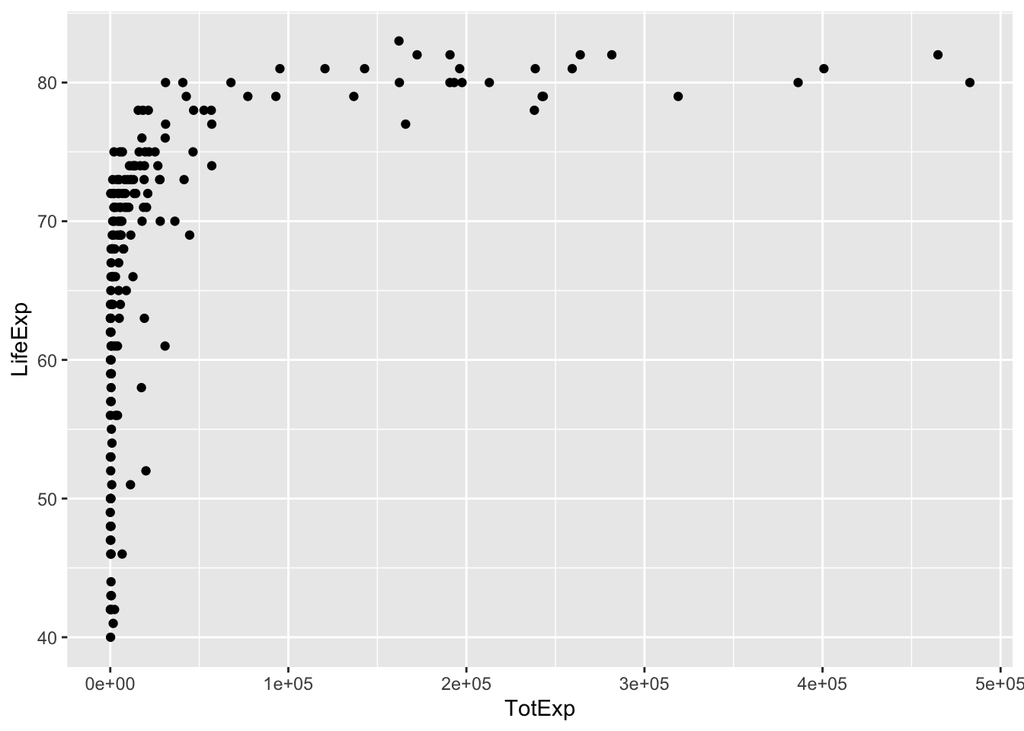

```r
library(ggplot2)
ggplot(dataset, aes(x = TotExp, y  = LifeExp)) +
  geom_point()
```

Simple linear regression

```r
regressor = lm(LifeExp ~ TotExp, data = dataset)
summary(regressor)
```

```
##
## Call:
## lm(formula = LifeExp ~ TotExp, data = dataset)
##
## Residuals:
##     Min      1Q  Median      3Q     Max
## -24.764  -4.778   3.154   7.116  13.292
##
## Coefficients:
##              Estimate Std. Error t value Pr(>|t|)
## (Intercept) 6.475e+01  7.535e-01  85.933  < 2e-16 ***
## TotExp      6.297e-05  7.795e-06   8.079 7.71e-14 ***
## ---
## Signif. codes:  0 '***' 0.001 '**' 0.01 '*' 0.05 '.' 0.1 ' ' 1
##
## Residual standard error: 9.371 on 188 degrees of freedom
## Multiple R-squared:  0.2577, Adjusted R-squared:  0.2537
## F-statistic: 65.26 on 1 and 188 DF,  p-value: 7.714e-14
```

Std. Error is an estimate of the standard deviation of the coefficient, the amount it varies across cases.

This model can not be presented by a simple linear regression. The Adjusted R-squared percent is too low, may be if we included more independent variables we can get a higher value.

## 2.

Raise life expectancy to the 4.6 power (i.e., LifeExp^4.6). Raise total expenditures to the 0.06 power (nearly a log transform, TotExp^.06). Plot LifeExp^4.6 as a function of TotExp^.06, and r re-run the simple regression model using the transformed variables. Provide and interpret the F statistics, R^2, standard error, and p-values. Which model is “better?”

```r
# raise LifeExp to 4.6 power
dataset$LifeExp_4.6 <- (dataset$LifeExp)^4.6
# raise TotExp to 0.06 power
dataset$TotExp_0.06 <- (dataset$TotExp)^0.06
head(dataset)
```

|  | Country | LifeExp | InfantSurvival | Under5Survival | TBFree | PropMD | PropRN | PersExp | GovtExp | TotExp | LifeExp_4.6 | TotExp_0.06 |
| --- | --- | --- | --- | --- | --- | --- | --- | --- | --- | --- | --- | --- |
| 1 | Afghanistan | 42 | 0.835 | 0.743 | 0.99769 | 0.000228841 | 0.000572294 | 20 | 92 | 112 | 29305338 | 1.327251 |
| 2 | Albania | 71 | 0.985 | 0.983 | 0.99974 | 0.001143127 | 0.004614439 | 169 | 3128 | 3297 | 327935478 | 1.625875 |
| 3 | Algeria | 71 | 0.967 | 0.962 | 0.99944 | 0.001060478 | 0.002091362 | 108 | 5184 | 5292 | 327935478 | 1.672697 |
| 4 | Andorra | 82 | 0.997 | 0.996 | 0.99983 | 0.003297297 | 0.003500000 | 2589 | 169725 | 172314 | 636126841 | 2.061481 |
| 5 | Angola | 41 | 0.846 | 0.740 | 0.99656 | 0.000070400 | 0.001146162 | 36 | 1620 | 1656 | 26230450 | 1.560068 |
| 6 | Antigua and Barbuda | 73 | 0.990 | 0.989 | 0.99991 | 0.000142857 | 0.002773810 | 503 | 12543 | 13046 | 372636298 | 1.765748 |

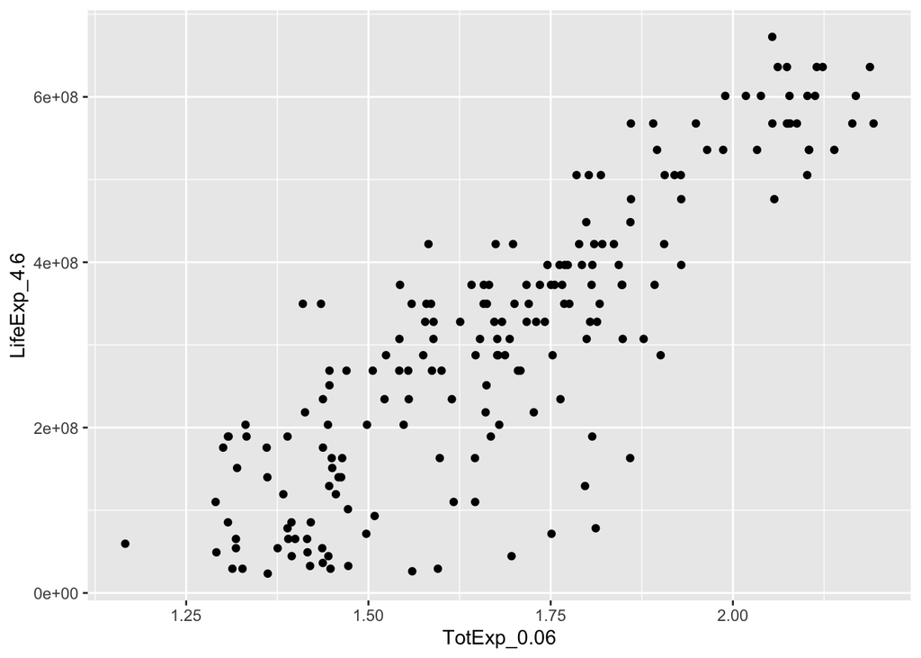

```r
ggplot(dataset, aes(x = TotExp_0.06, y  = LifeExp_4.6)) +
  geom_point()
```

```r
regressor_2 = lm(LifeExp_4.6 ~ TotExp_0.06, data = dataset)
summary(regressor_2)
```

```
##
## Call:
## lm(formula = LifeExp_4.6 ~ TotExp_0.06, data = dataset)
##
## Residuals:
##        Min         1Q     Median         3Q        Max
## -308616089  -53978977   13697187   59139231  211951764
##
## Coefficients:
##               Estimate Std. Error t value Pr(>|t|)
## (Intercept) -736527910   46817945  -15.73   <2e-16 ***
## TotExp_0.06  620060216   27518940   22.53   <2e-16 ***
## ---
## Signif. codes:  0 '***' 0.001 '**' 0.01 '*' 0.05 '.' 0.1 ' ' 1
##
## Residual standard error: 90490000 on 188 degrees of freedom
## Multiple R-squared:  0.7298, Adjusted R-squared:  0.7283
## F-statistic: 507.7 on 1 and 188 DF,  p-value: < 2.2e-16
```

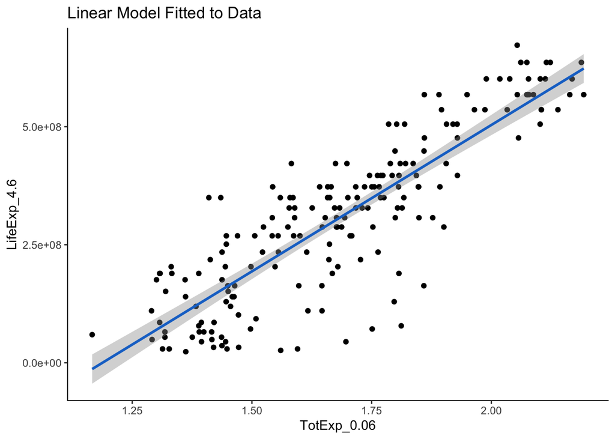

```r
ggplot(data = dataset, aes(x = TotExp_0.06, y = LifeExp_4.6)) +
geom_point() +
stat_smooth(method = "lm", col = "dodgerblue3") +
theme(panel.background = element_rect(fill = "white"),
axis.line.x=element_line(),
axis.line.y=element_line()) +
ggtitle("Linear Model Fitted to Data")
```

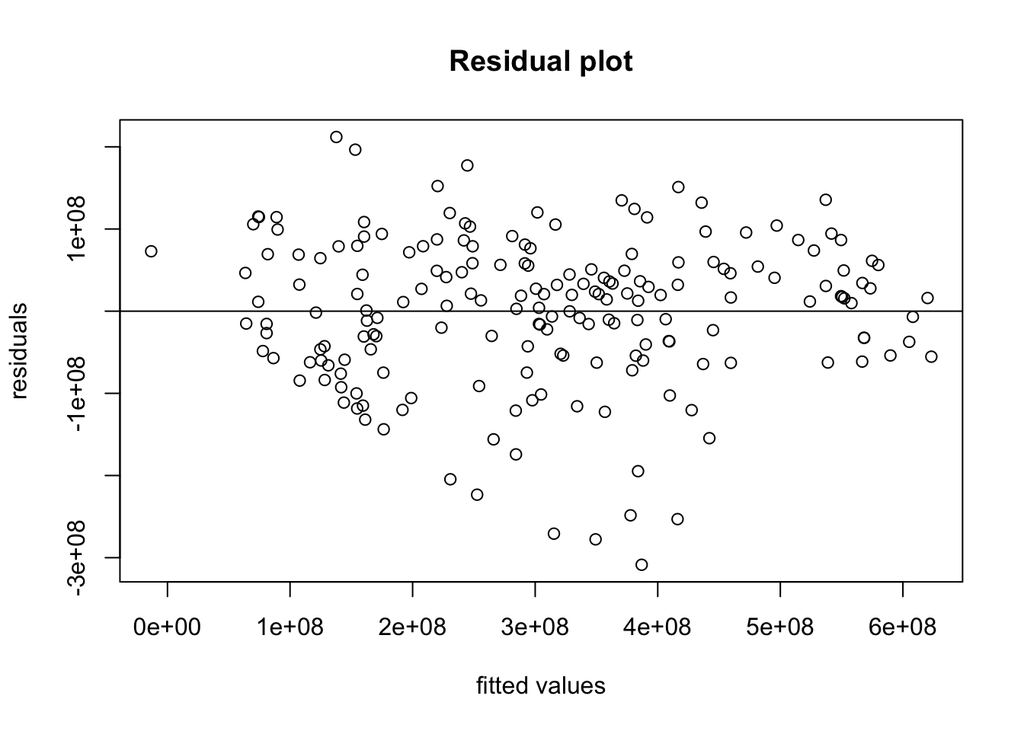

```r
plot(regressor_2$fitted.values, regressor_2$residuals,
     xlab = 'fitted values',
     ylab = 'residuals',
     main = 'Residual plot')
abline(h=0)
```

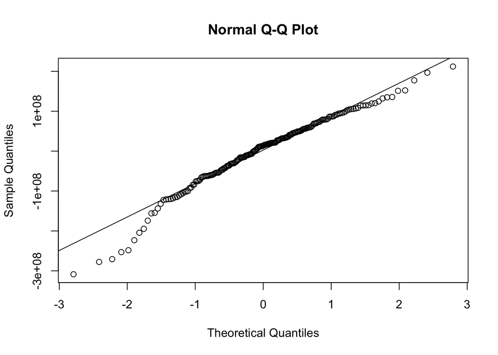

```r
# Residuals Q-Q plot
qqnorm(regressor_2$residuals)
qqline(regressor_2$residuals)
```

P-value: is still less than 0.05 significance level (2e-16) ,but F-Statistic got higher 507.7, so we can be sure that TotExp independent variable affecting the LifeExp. We can reject the null hypothesis. Moreover, the R-squared got better as well (72.8%), which means that the model would explain about 72.8% of the model variability.

Std. Error is an estimate of the standard deviation of the coefficient, the amount it varies across cases.

This model Definitly is better than the previous one.

## 3.

Using the results from 2, forecast life expectancy when TotExp^.06 =1.5. Then forecast life expectancy when TotExp^.06=2.5.

```r
predict(regressor_2, data.frame(TotExp_0.06=c(1.5, 2.5)), interval = 'predict')^(1/4.6)
```

```
##        fit      lwr      upr
## 1 63.31153 35.93545 73.00793
## 2 86.50645 81.80643 90.43414
```

## 4.

Build the following multiple regression model and interpret the F Statistics, R^2, standard error, and p-values. How good is the model? LifeExp = b0+b1 x PropMd + b2 x TotExp +b3 x PropMD x TotExp

```r
regressor_3 <- lm(LifeExp ~ PropMD + TotExp + TotExp:PropMD, data = dataset)
summary(regressor_3)
```

```
##
## Call:
## lm(formula = LifeExp ~ PropMD + TotExp + TotExp:PropMD, data = dataset)
##
## Residuals:
##     Min      1Q  Median      3Q     Max
## -27.320  -4.132   2.098   6.540  13.074
##
## Coefficients:
##                 Estimate Std. Error t value Pr(>|t|)
## (Intercept)    6.277e+01  7.956e-01  78.899  < 2e-16 ***
## PropMD         1.497e+03  2.788e+02   5.371 2.32e-07 ***
## TotExp         7.233e-05  8.982e-06   8.053 9.39e-14 ***
## PropMD:TotExp -6.026e-03  1.472e-03  -4.093 6.35e-05 ***
## ---
## Signif. codes:  0 '***' 0.001 '**' 0.01 '*' 0.05 '.' 0.1 ' ' 1
##
## Residual standard error: 8.765 on 186 degrees of freedom
## Multiple R-squared:  0.3574, Adjusted R-squared:  0.3471
## F-statistic: 34.49 on 3 and 186 DF,  p-value: < 2.2e-16
```

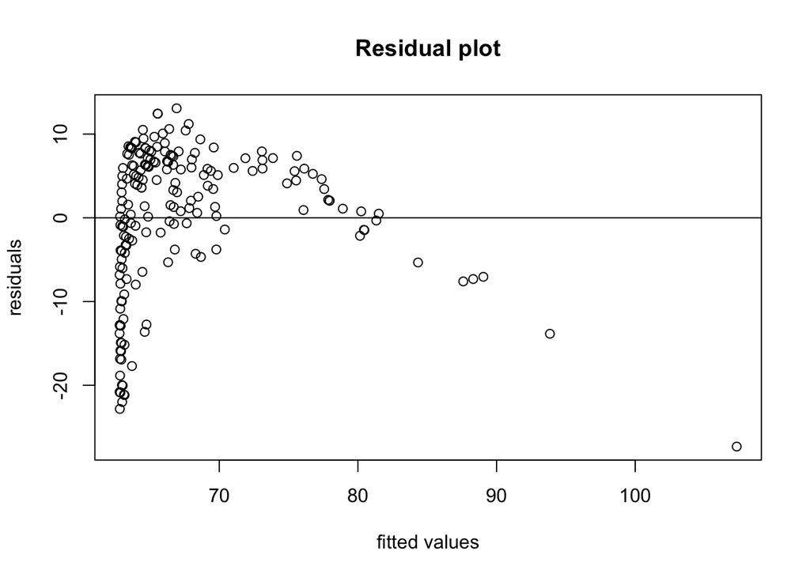

```r
plot(regressor_3$fitted.values, regressor_3$residuals,
     xlab = 'fitted values',
     ylab = 'residuals',
     main = 'Residual plot')
abline(h=0)
```

[figure not shown]

```r
# Residuals Q-Q plot
qqnorm(regressor_2$residuals)
qqline(regressor_2$residuals)
```

Residual standard error is 8.765 and F-statistic is 34.49. Considering that average life expectancy is 67.38, the SE is not terrible and F-statistics is fairly high (but lower than in the first model). R2 is only 0.3574, so the model explains only 35.74% of variability, which is not high. P-value is nearly 0, so the relationship is not due to random variation.

## 5.

Forecast LifeExp when PropMD=.03 and TotExp = 14. Does this forecast seem realistic? Why or why not?

```r
predict(regressor_3, data.frame(PropMD = 0.03, TotExp = 14), interval = 'predict')
```

```
##       fit      lwr      upr
## 1 107.696 84.24791 131.1441
```